# COVID-19 Massachusetts Forecast Hub report, 2020-08-17

Nicholas G Reich, Estee Y Cramer, Martha Zorn

2020-08-24

# Background

This report provides a brief summary of the weekly ensemble forecast for Massachusetts from the [COVID-19 Forecast Hub](https://covid19forecasthub.org/). In collaboration with the US CDC, our team aggregates COVID-19 forecasts from dozens of teams around the globe. Typically on Wednesday or Thursday of each week, a summary of the week’s forecasts from the COVID-19 Forecast Hub appear on the [official CDC COVID-19 forecasting page](https://www.cdc.gov/coronavirus/2019-ncov/covid-data/forecasting-us.html).

Every week, teams submit their forecasts to the COVID-19 Forecast Hub.

Each Tuesday, we combine the most recent forecasts from each team into a single “ensemble” forecast of reported COVID-19 cases at the county, state, and national level and deaths at the state and national level. At the moment, we only generate ensemble forecasts for four weeks into the future, as we don’t have reliable evidence that the models are accurate past that horizon.

Weekly reports from the COVID-19 Forecast Hub can be found at [this page](https://covid19forecasthub.org/doc/reports/). We expect that these reports will become more detailed as the weeks go on.

# COVID-19 Mortality Forecasts

Since the inputs to the ensemble model do not factor in changes in behavior or policy that could have an impact on short-term disease transmission (e.g. school openings or closures, new interventions, governmental policy shift, etc…), the ensemble model itself should not be looked to for specific answers to questions like “what will happen if or when schools open in 2 weeks” because most of the input models are not factoring in these changes. That said, the ensemble model has consistently shown strong predictive performance, and very few of the many interventions put in place appear to have created dramatic changes in short-term disease transmission.

## State level

This week, our ensemble combined forecasts for Massachusetts from 31 different models.

At the state level, the ensemble model’s best guess is that we will see between 70 and 100 deaths each week for the next four weeks with around 9,000 deaths by September 12 (Figure 1). However for the week ending September 12, the ensemble shows substantial uncertainty, with observed deaths between 30 and 190 deemed possible (95% prediction interval: 28 - 194).

Throughought most of July, models have in general shown broad agreement about the trajectory of the outbreak over the coming weeks. However, the recent surge in cases has left models with quite different interpretations about what the next few weeks hold in terms of how many reported deaths from COVID-19 we will see. You can explore the full set of models, including their forecasts for past weeks online at our [interactive forecast visualization](https://viz.covid19forecasthub.org/).

Figure 1: Weekly observed and forecasted COVID-19 deaths. Observed data from [JHU CSSE](https://github.com/CSSEGISandData/COVID-19/tree/master/csse_covid_19_data/) and forecasts from the [COVID-19 Forecast Hub](https://covid19forecasthub.org/).

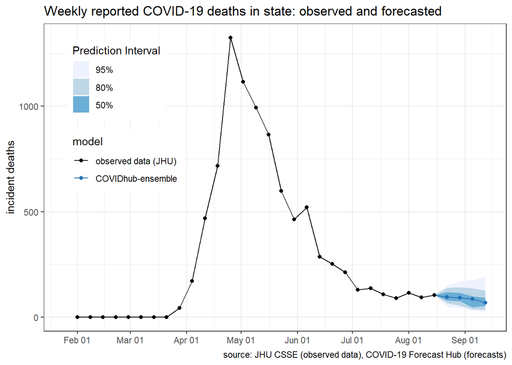

The sortable and searchable table below shows the total number of reported COVID-19 deaths at the US level and for Massachusetts over the last two weeks (ending Saturday, August 15, 2020) and the forecasted counts for the subsequent two weeks (ending August 29, 2020).

| county | Population | Total COVID-19 deaths | COVID-19 deaths, last 2 weeks | COVID-19 deaths, next 2 weeks | Difference |
| --- | --- | --- | --- | --- | --- |
| Massachusetts | 6892503 | 8826 | 200 | 194 | -6 |
| US | 329466283 | 169481 | 14322 | 13222 | -1100 |

# COVID-19 Incidence of Cases Forecasts

## State level

At the state level, the ensemble model’s best guess is that we will see between 1,700 and 2,400 cases each week for the next four weeks (Figure 2). However for the week ending September 12, the ensemble shows substantial uncertainty, with observed deaths between 500 and 4,060).

Figure 2: Weekly observed and forecasted COVID-19 Cases. Observed data from [JHU CSSE](https://github.com/CSSEGISandData/COVID-19/tree/master/csse_covid_19_data/) and forecasts from the [COVID-19 Forecast Hub](https://covid19forecasthub.org/).

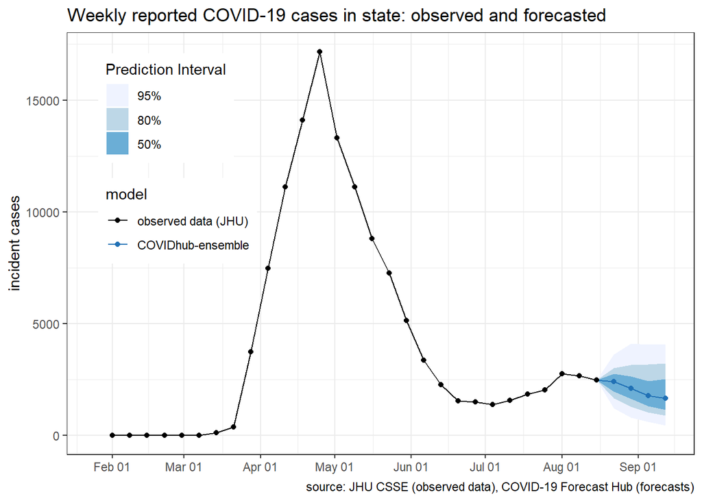

The sortable and searchable table below shows the total number of reported COVID-19 cases at the US and state level for Massachusetts as of Saturday,August 15, 2020 (“Total COVID-19 Cases”) as well as the rate of reported COVID-19 cases in the population (standardized per 100,000 population) over the last two weeks and over the next two weeks.

| county | Population | Total COVID-19 cases | Daily case count last week | Daily cases per 100k, last week | Predicted case counts, 2 week ahead | Predicted daily cases per 100k, 2 weeks ahead | Probability 2 week ahead case count >= previous week |
| --- | --- | --- | --- | --- | --- | --- | --- |
| US | 329466283 | 5361165 | 363236 | 15.75 | 302336 | 13.109 | 0.1 |
| Massachusetts | 6892503 | 123199 | 2488 | 5.157 | 2103 | 4.359 | 0.25 |

## County level

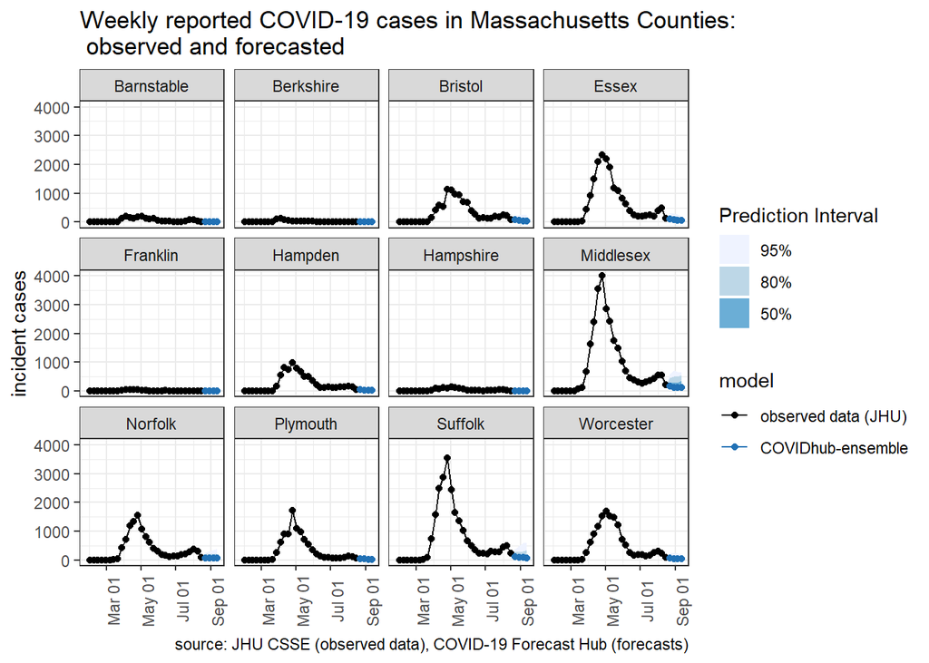

The figure below examines the counties with low incidence of cases.

Figure 4: Weekly observed and forecasted COVID-19 Cases by County for Counties with Low Incidence. Observed data from [JHU CSSE](https://github.com/CSSEGISandData/COVID-19/tree/master/csse_covid_19_data/) and forecasts from the [COVID-19 Forecast Hub](https://covid19forecasthub.org/).

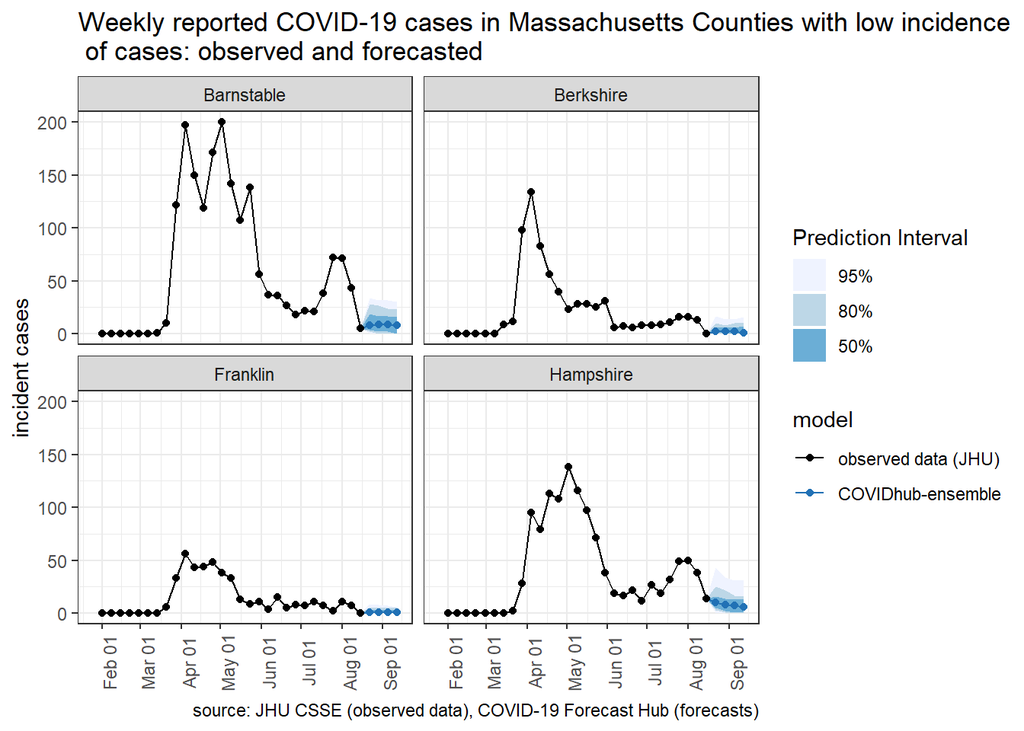

The sortable and searchable table below shows the total number of reported COVID-19 cases at the county level for Massachusetts as of Saturday,August 15, 2020 (“Total COVID-19 Cases”) as well as the rate of reported COVID-19 cases in the population (standardized per 100,000 population) over the last two weeks and over the next two weeks.

Looking at the rates allows for easier comparison across counties, where you can see which counties have had or are predicted to have propoportionally higher rates in comparison to other counties. These tables calculate an average daily number of cases per 100,000 population across the last two weeks (ending Saturday, August 15, 2020) and forecasted for the following two weeks (ending August 29, 2020).

| county | Population | Total COVID-19 cases | Daily case count last week | Daily cases per 100k, last week | Predicted case counts, 2 week ahead | Predicted daily cases per 100k, 2 weeks ahead | Probability 2 week ahead case count >= previous week |
| --- | --- | --- | --- | --- | --- | --- | --- |
| Suffolk County | 803907 | 22017 | 239 | 4.247 | 96 | 1.706 | 0.1 |
| Essex County | 789034 | 17930 | 141 | 2.553 | 75 | 1.358 | 0.25 |
| Bristol County | 565217 | 9408 | 84 | 2.123 | 52 | 1.314 | 0.25 |
| Norfolk County | 706775 | 10682 | 81 | 1.637 | 62 | 1.253 | 0.25 |
| Middlesex County | 1611699 | 26565 | 220 | 1.95 | 134 | 1.188 | 0.25 |
| Plymouth County | 521202 | 9288 | 62 | 1.699 | 33 | 0.905 | 0.1 |
| Worcester County | 830622 | 13686 | 84 | 1.445 | 51 | 0.877 | 0.25 |
| Hampden County | 466372 | 7637 | 55 | 1.685 | 28 | 0.858 | 0.25 |
| Hampshire County | 160830 | 1184 | 14 | 1.244 | 8 | 0.711 | 0.25 |
| Barnstable County | 212990 | 1803 | 5 | 0.335 | 9 | 0.604 | 0.5 |

[output cut: 2 more lines]

This report was reproducibly and dynamically generated using RMarkdown. The code for the report can be found [here](https://github.com/reichlab/covid19-forecast-hub/tree/master/code/reports).